# Downloading Required packages

```python
import pandas
import numpy
import matplotlib
import seaborn
import scipy
import sklearn
```

```python
from pydoc import help  # can type in the python console `help(name of function)` to get the documentation
import pandas as pd
import numpy as np
import matplotlib.pyplot as plt
import seaborn as sns
from sklearn.preprocessing import scale
from sklearn.decomposition import PCA
from sklearn.discriminant_analysis import LinearDiscriminantAnalysis
#from sklearn.linear_model import LinearRegression
from scipy import stats
from IPython.display import display, HTML

# figures inline in notebook
%matplotlib inline

np.set_printoptions(suppress=True)

DISPLAY_MAX_ROWS = 20  # number of max rows to print for a DataFrame
pd.set_option('display.max_rows', DISPLAY_MAX_ROWS)
```

```python
data = pd.read_csv("/home/tpc/hs/ml_CompiledDataset-5-7dns-300sf-100sf-q1.csv", sep=',',error_bad_lines=False)
data.columns = ["V"+str(i) for i in range(1, len(data.columns)+1)]  # rename column names
data.V1 = data.V1.astype(str).astype(int)
data.V2 = data.V2.astype(str).astype(int)
data.V3 = data.V3.astype(str).astype(int)
data.V4 = data.V4.astype(str).astype(int)
data.V5 = data.V5.astype(str).astype(int)
data.V6 = data.V6.astype(str).astype(int)
data.V7 = data.V7.astype(str).astype(int)
data.V8 = data.V8.astype(str).astype(int)
data.V9 = data.V9.astype(str).astype(int)
data.V10 = data.V10.astype(str).astype(int)
data.V11 = data.V11.astype(str).astype(float)
data.V12 = data.V12.astype(str).astype(float)
data.V13 = data.V13.astype(str) # Tuning comment
data.V14 = data.V14.astype(str).astype(float) # Query Run time

X = data.loc[1:, "V1":"V12"]  # independent variables data
y = data.V14
Cname=data.V1
```

```python
data
```

|  | V1 | V2 | V3 | V4 | V5 | V6 | V7 | V8 | V9 | V10 | V11 | V12 | V13 | V14 |
| --- | --- | --- | --- | --- | --- | --- | --- | --- | --- | --- | --- | --- | --- | --- |
| 0 | 5 | 300 | 250880 | 63 | 8192 | 4096 | 8192 | 4096 | 295 | 67108864 | 2097152.0 | 0.75 | Row1Query1 | 162.961 |
| 1 | 5 | 300 | 245760 | 50 | 8192 | 2048 | 8192 | 2048 | 315 | 134217728 | 524288.0 | 0.90 | Row2Query1 | 192.549 |
| 2 | 5 | 300 | 240640 | 45 | 16384 | 2048 | 16384 | 2048 | 295 | 268435456 | 1048576.0 | 0.25 | Row3Query1 | 182.325 |
| 3 | 5 | 300 | 245760 | 50 | 4096 | 16384 | 4096 | 16384 | 295 | 536870912 | 524288.0 | 0.75 | Row4Query1 | 206.556 |
| 4 | 5 | 300 | 250880 | 63 | 4096 | 2048 | 4096 | 2048 | 290 | 268435456 | 1048576.0 | 0.50 | Row5Query1 | 187.959 |
| 5 | 5 | 300 | 240640 | 45 | 16384 | 16384 | 16384 | 16384 | 315 | 268435456 | 4194304.0 | 0.75 | Row6Query1 | 178.446 |
| 6 | 5 | 300 | 240640 | 63 | 2048 | 16384 | 2048 | 16384 | 315 | 134217728 | 524288.0 | 0.25 | Row7Query1 | 174.503 |
| 7 | 5 | 300 | 240640 | 63 | 4096 | 2048 | 4096 | 2048 | 295 | 134217728 | 2097152.0 | 0.25 | Row8Query1 | 158.778 |
| 8 | 5 | 300 | 240640 | 45 | 2048 | 2048 | 2048 | 2048 | 295 | 67108864 | 2097152.0 | 0.25 | Row9Query1 | 162.640 |
| 9 | 5 | 300 | 240640 | 63 | 2048 | 2048 | 2048 | 2048 | 290 | 268435456 | 4194304.0 | 0.75 | Row10Query1 | 177.117 |
| ... | ... | ... | ... | ... | ... | ... | ... | ... | ... | ... | ... | ... | ... | ... |
| 1778 | 7 | 100 | 245760 | 63 | 8192 | 2048 | 8192 | 2048 | 441 | 134217728 | 2097152.0 | 0.90 | Row989Query1 | 161.305 |
| 1779 | 7 | 100 | 240640 | 45 | 2048 | 16384 | 2048 | 16384 | 430 | 268435456 | 4194304.0 | 0.90 | Row990Query1 | 160.217 |
| 1780 | 7 | 100 | 256000 | 50 | 4096 | 16384 | 4096 | 16384 | 425 | 67108864 | 524288.0 | 0.75 | Row991Query1 | 170.555 |
| 1781 | 7 | 100 | 250880 | 45 | 4096 | 2048 | 4096 | 2048 | 435 | 67108864 | 524288.0 | 0.75 | Row992Query1 | 171.663 |
| 1782 | 7 | 100 | 256000 | 45 | 16384 | 8192 | 16384 | 8192 | 425 | 268435456 | 2097152.0 | 0.75 | Row993Query1 | 161.304 |
| 1783 | 7 | 100 | 250880 | 63 | 2048 | 8192 | 2048 | 8192 | 435 | 536870912 | 4194304.0 | 0.50 | Row995Query1 | 151.724 |
| 1784 | 7 | 100 | 250880 | 63 | 2048 | 2048 | 2048 | 2048 | 441 | 268435456 | 1048576.0 | 0.25 | Row996Query1 | 173.991 |
| 1785 | 7 | 100 | 240640 | 63 | 16384 | 2048 | 16384 | 2048 | 425 | 67108864 | 2097152.0 | 0.75 | Row997Query1 | 150.368 |
| 1786 | 7 | 100 | 240640 | 50 | 16384 | 2048 | 16384 | 2048 | 430 | 268435456 | 524288.0 | 0.75 | Row998Query1 | 182.914 |
| 1787 | 7 | 100 | 250880 | 50 | 16384 | 2048 | 16384 | 2048 | 435 | 134217728 | 524288.0 | 0.75 | Row1000Query1 | 176.420 |

1788 rows × 14 columns

```python
#removed rows with nan values
data.dropna(inplace=True, axis=0)
```

```python
#Dropping Tuning comment as it does not form part of feature-set
data.drop(["V1","V2","V13"],inplace=True,axis=1)
```

```python
data.columns = ("yn.res-memory-gb","yn.res-cpu-vcores","mr.map.memory.mb","mr.reduce.memory.mb","mr.map.java.opts","mr.reduce.java.opts","hive.exec.reducers.max","blocksize.split.maxsize","hive.exec.reducers.bytes.per.reducer","mapreduce.job.reduce.slowstart.completedmaps","RunTime-Query1-secs")
```

```python
data
```

|  | yn.res-memory-gb | yn.res-cpu-vcores | mr.map.memory.mb | mr.reduce.memory.mb | mr.map.java.opts | mr.reduce.java.opts | hive.exec.reducers.max | blocksize.split.maxsize | hive.exec.reducers.bytes.per.reducer | mapreduce.job.reduce.slowstart.completedmaps | RunTime-Query1-secs |
| --- | --- | --- | --- | --- | --- | --- | --- | --- | --- | --- | --- |
| 0 | 250880 | 63 | 8192 | 4096 | 8192 | 4096 | 295 | 67108864 | 2097152.0 | 0.75 | 162.961 |
| 1 | 245760 | 50 | 8192 | 2048 | 8192 | 2048 | 315 | 134217728 | 524288.0 | 0.90 | 192.549 |
| 2 | 240640 | 45 | 16384 | 2048 | 16384 | 2048 | 295 | 268435456 | 1048576.0 | 0.25 | 182.325 |
| 3 | 245760 | 50 | 4096 | 16384 | 4096 | 16384 | 295 | 536870912 | 524288.0 | 0.75 | 206.556 |
| 4 | 250880 | 63 | 4096 | 2048 | 4096 | 2048 | 290 | 268435456 | 1048576.0 | 0.50 | 187.959 |
| 5 | 240640 | 45 | 16384 | 16384 | 16384 | 16384 | 315 | 268435456 | 4194304.0 | 0.75 | 178.446 |
| 6 | 240640 | 63 | 2048 | 16384 | 2048 | 16384 | 315 | 134217728 | 524288.0 | 0.25 | 174.503 |
| 7 | 240640 | 63 | 4096 | 2048 | 4096 | 2048 | 295 | 134217728 | 2097152.0 | 0.25 | 158.778 |
| 8 | 240640 | 45 | 2048 | 2048 | 2048 | 2048 | 295 | 67108864 | 2097152.0 | 0.25 | 162.640 |
| 9 | 240640 | 63 | 2048 | 2048 | 2048 | 2048 | 290 | 268435456 | 4194304.0 | 0.75 | 177.117 |
| ... | ... | ... | ... | ... | ... | ... | ... | ... | ... | ... | ... |
| 1778 | 245760 | 63 | 8192 | 2048 | 8192 | 2048 | 441 | 134217728 | 2097152.0 | 0.90 | 161.305 |
| 1779 | 240640 | 45 | 2048 | 16384 | 2048 | 16384 | 430 | 268435456 | 4194304.0 | 0.90 | 160.217 |
| 1780 | 256000 | 50 | 4096 | 16384 | 4096 | 16384 | 425 | 67108864 | 524288.0 | 0.75 | 170.555 |
| 1781 | 250880 | 45 | 4096 | 2048 | 4096 | 2048 | 435 | 67108864 | 524288.0 | 0.75 | 171.663 |
| 1782 | 256000 | 45 | 16384 | 8192 | 16384 | 8192 | 425 | 268435456 | 2097152.0 | 0.75 | 161.304 |
| 1783 | 250880 | 63 | 2048 | 8192 | 2048 | 8192 | 435 | 536870912 | 4194304.0 | 0.50 | 151.724 |
| 1784 | 250880 | 63 | 2048 | 2048 | 2048 | 2048 | 441 | 268435456 | 1048576.0 | 0.25 | 173.991 |
| 1785 | 240640 | 63 | 16384 | 2048 | 16384 | 2048 | 425 | 67108864 | 2097152.0 | 0.75 | 150.368 |
| 1786 | 240640 | 50 | 16384 | 2048 | 16384 | 2048 | 430 | 268435456 | 524288.0 | 0.75 | 182.914 |
| 1787 | 250880 | 50 | 16384 | 2048 | 16384 | 2048 | 435 | 134217728 | 524288.0 | 0.75 | 176.420 |

1788 rows × 11 columns

### Below we see the mean of all independent variables considered in the dataset

```python
data.apply(np.mean)
```

```
yn.res-memory-gb                                2.483143e+05
yn.res-cpu-vcores                               5.266387e+01
mr.map.memory.mb                                7.659383e+03
mr.reduce.memory.mb                             7.671982e+03
mr.map.java.opts                                7.659383e+03
mr.reduce.java.opts                             7.671982e+03
hive.exec.reducers.max                          3.585839e+02
blocksize.split.maxsize                         2.532722e+08
hive.exec.reducers.bytes.per.reducer            1.961388e+06
mapreduce.job.reduce.slowstart.completedmaps    6.001678e-01
RunTime-Query1-secs                             1.763119e+02
dtype: float64
```

### Below standard deviation is calculated for all X variables

```python
data.apply(np.std)
```

```
yn.res-memory-gb                                5.698661e+03
yn.res-cpu-vcores                               7.588441e+00
mr.map.memory.mb                                5.492472e+03
mr.reduce.memory.mb                             5.499867e+03
mr.map.java.opts                                5.492472e+03
mr.reduce.java.opts                             5.499867e+03
hive.exec.reducers.max                          6.648381e+01
blocksize.split.maxsize                         1.807360e+08
hive.exec.reducers.bytes.per.reducer            1.399335e+06
mapreduce.job.reduce.slowstart.completedmaps    2.475833e-01
RunTime-Query1-secs                             2.269972e+01
dtype: float64
```

### Since the mean and standard deviation for the above variables is not comparable lets standardise it.

### Lets calculate the mean and standard deviations of the above variables - new DNs, SF removed dataset

```python
class2data = data
```

```python
tpcData =class2data.loc[:,"yn.res-memory-gb":"RunTime-Query1-secs"]
```

```python
tpcData.apply(np.mean)
```

```
yn.res-memory-gb                                2.483143e+05
yn.res-cpu-vcores                               5.266387e+01
mr.map.memory.mb                                7.659383e+03
mr.reduce.memory.mb                             7.671982e+03
mr.map.java.opts                                7.659383e+03
mr.reduce.java.opts                             7.671982e+03
hive.exec.reducers.max                          3.585839e+02
blocksize.split.maxsize                         2.532722e+08
hive.exec.reducers.bytes.per.reducer            1.961388e+06
mapreduce.job.reduce.slowstart.completedmaps    6.001678e-01
RunTime-Query1-secs                             1.763119e+02
dtype: float64
```

```python
tpcData.apply(np.std)
```

```
yn.res-memory-gb                                5.698661e+03
yn.res-cpu-vcores                               7.588441e+00
mr.map.memory.mb                                5.492472e+03
mr.reduce.memory.mb                             5.499867e+03
mr.map.java.opts                                5.492472e+03
mr.reduce.java.opts                             5.499867e+03
hive.exec.reducers.max                          6.648381e+01
blocksize.split.maxsize                         1.807360e+08
hive.exec.reducers.bytes.per.reducer            1.399335e+06
mapreduce.job.reduce.slowstart.completedmaps    2.475833e-01
RunTime-Query1-secs                             2.269972e+01
dtype: float64
```

```python
# A function for calculating the mean and standard deviation for different groups
def printMeanAndSdByGroup(variables, groupvariable):
    data_groupby = variables.groupby(groupvariable)
    print("## Means:")
    display(data_groupby.apply(np.mean))
    print("\n## Standard deviations:")
    display(data_groupby.apply(np.std))
    print("\n## Sample sizes:")
    display(pd.DataFrame(data_groupby.apply(len)))
```

```python
printMeanAndSdByGroup(X, Cname)
```

```
## Means:
```

| V1 | V1 | V2 | V3 | V4 | V5 | V6 | V7 | V8 | V9 | V10 | V11 | V12 |
| --- | --- | --- | --- | --- | --- | --- | --- | --- | --- | --- | --- | --- |
| 5 | 5.0 | 300.0 | 248327.687688 | 52.627628 | 7654.886887 | 7704.088088 | 7654.886887 | 7704.088088 | 300.005005 | 2.522460e+08 | 1.963850e+06 | 0.60000 |
| 7 | 7.0 | 100.0 | 248294.010152 | 52.696701 | 7664.406091 | 7635.817259 | 7664.406091 | 7635.817259 | 432.928934 | 2.548093e+08 | 1.958096e+06 | 0.60019 |

```
## Standard deviations:
```

| V1 | V1 | V2 | V3 | V4 | V5 | V6 | V7 | V8 | V9 | V10 | V11 | V12 |
| --- | --- | --- | --- | --- | --- | --- | --- | --- | --- | --- | --- | --- |
| 5 | 0.0 | 0.0 | 5717.448642 | 7.566686 | 5481.777867 | 5504.711543 | 5481.777867 | 5504.711543 | 9.336066 | 1.797219e+08 | 1.406873e+06 | 0.247955 |
| 7 | 0.0 | 0.0 | 5677.592135 | 7.611649 | 5509.437625 | 5495.497835 | 5509.437625 | 5495.497835 | 6.017953 | 1.819964e+08 | 1.390598e+06 | 0.247212 |

```
## Sample sizes:
```

| V1 | 0 |
| --- | --- |
| 5 | 999 |
| 7 | 788 |

```python
corrmat = tpcData.corr()
corrmat
```

|  | yn.res-memory-gb | yn.res-cpu-vcores | mr.map.memory.mb | mr.reduce.memory.mb | mr.map.java.opts | mr.reduce.java.opts | hive.exec.reducers.max | blocksize.split.maxsize | hive.exec.reducers.bytes.per.reducer | mapreduce.job.reduce.slowstart.completedmaps | RunTime-Query1-secs |
| --- | --- | --- | --- | --- | --- | --- | --- | --- | --- | --- | --- |
| yn.res-memory-gb | 1.000000 | 0.018331 | 0.010676 | 0.036767 | 0.010676 | 0.036767 | -0.003211 | 0.011670 | -0.003957 | -0.037242 | -0.013228 |
| yn.res-cpu-vcores | 0.018331 | 1.000000 | 0.021922 | -0.008552 | 0.021922 | -0.008552 | 0.002285 | -0.017947 | -0.013907 | 0.001414 | -0.027294 |
| mr.map.memory.mb | 0.010676 | 0.021922 | 1.000000 | -0.006839 | 1.000000 | -0.006839 | 0.000478 | -0.017273 | -0.048554 | 0.019018 | -0.015975 |
| mr.reduce.memory.mb | 0.036767 | -0.008552 | -0.006839 | 1.000000 | -0.006839 | 1.000000 | -0.004388 | -0.008319 | 0.008071 | -0.029083 | -0.004317 |
| mr.map.java.opts | 0.010676 | 0.021922 | 1.000000 | -0.006839 | 1.000000 | -0.006839 | 0.000478 | -0.017273 | -0.048554 | 0.019018 | -0.015975 |
| mr.reduce.java.opts | 0.036767 | -0.008552 | -0.006839 | 1.000000 | -0.006839 | 1.000000 | -0.004388 | -0.008319 | 0.008071 | -0.029083 | -0.004317 |
| hive.exec.reducers.max | -0.003211 | 0.002285 | 0.000478 | -0.004388 | 0.000478 | -0.004388 | 1.000000 | 0.004045 | 0.001397 | -0.002184 | -0.425787 |
| blocksize.split.maxsize | 0.011670 | -0.017947 | -0.017273 | -0.008319 | -0.017273 | -0.008319 | 0.004045 | 1.000000 | 0.023917 | 0.018049 | 0.505625 |
| hive.exec.reducers.bytes.per.reducer | -0.003957 | -0.013907 | -0.048554 | 0.008071 | -0.048554 | 0.008071 | 0.001397 | 0.023917 | 1.000000 | 0.014750 | -0.270181 |
| mapreduce.job.reduce.slowstart.completedmaps | -0.037242 | 0.001414 | 0.019018 | -0.029083 | 0.019018 | -0.029083 | -0.002184 | 0.018049 | 0.014750 | 1.000000 | 0.160080 |
| RunTime-Query1-secs | -0.013228 | -0.027294 | -0.015975 | -0.004317 | -0.015975 | -0.004317 | -0.425787 | 0.505625 | -0.270181 | 0.160080 | 1.000000 |

```python
corrmat.sort_values(["RunTime-Query1-secs"],ascending=False,inplace=True)
```

```python
corrmat
```

|  | yn.res-memory-gb | yn.res-cpu-vcores | mr.map.memory.mb | mr.reduce.memory.mb | mr.map.java.opts | mr.reduce.java.opts | hive.exec.reducers.max | blocksize.split.maxsize | hive.exec.reducers.bytes.per.reducer | mapreduce.job.reduce.slowstart.completedmaps | RunTime-Query1-secs |
| --- | --- | --- | --- | --- | --- | --- | --- | --- | --- | --- | --- |
| RunTime-Query1-secs | -0.013228 | -0.027294 | -0.015975 | -0.004317 | -0.015975 | -0.004317 | -0.425787 | 0.505625 | -0.270181 | 0.160080 | 1.000000 |
| blocksize.split.maxsize | 0.011670 | -0.017947 | -0.017273 | -0.008319 | -0.017273 | -0.008319 | 0.004045 | 1.000000 | 0.023917 | 0.018049 | 0.505625 |
| mapreduce.job.reduce.slowstart.completedmaps | -0.037242 | 0.001414 | 0.019018 | -0.029083 | 0.019018 | -0.029083 | -0.002184 | 0.018049 | 0.014750 | 1.000000 | 0.160080 |
| mr.reduce.memory.mb | 0.036767 | -0.008552 | -0.006839 | 1.000000 | -0.006839 | 1.000000 | -0.004388 | -0.008319 | 0.008071 | -0.029083 | -0.004317 |
| mr.reduce.java.opts | 0.036767 | -0.008552 | -0.006839 | 1.000000 | -0.006839 | 1.000000 | -0.004388 | -0.008319 | 0.008071 | -0.029083 | -0.004317 |
| yn.res-memory-gb | 1.000000 | 0.018331 | 0.010676 | 0.036767 | 0.010676 | 0.036767 | -0.003211 | 0.011670 | -0.003957 | -0.037242 | -0.013228 |
| mr.map.memory.mb | 0.010676 | 0.021922 | 1.000000 | -0.006839 | 1.000000 | -0.006839 | 0.000478 | -0.017273 | -0.048554 | 0.019018 | -0.015975 |
| mr.map.java.opts | 0.010676 | 0.021922 | 1.000000 | -0.006839 | 1.000000 | -0.006839 | 0.000478 | -0.017273 | -0.048554 | 0.019018 | -0.015975 |
| yn.res-cpu-vcores | 0.018331 | 1.000000 | 0.021922 | -0.008552 | 0.021922 | -0.008552 | 0.002285 | -0.017947 | -0.013907 | 0.001414 | -0.027294 |
| hive.exec.reducers.bytes.per.reducer | -0.003957 | -0.013907 | -0.048554 | 0.008071 | -0.048554 | 0.008071 | 0.001397 | 0.023917 | 1.000000 | 0.014750 | -0.270181 |
| hive.exec.reducers.max | -0.003211 | 0.002285 | 0.000478 | -0.004388 | 0.000478 | -0.004388 | 1.000000 | 0.004045 | 0.001397 | -0.002184 | -0.425787 |

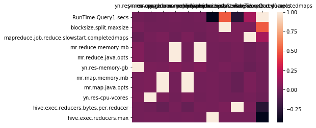

```python
sns.heatmap(corrmat, vmax=1., square=False).xaxis.tick_top()
```

### Better visualization of the input paramters vs Query1 execution-time of the TPCx-BB data, is below

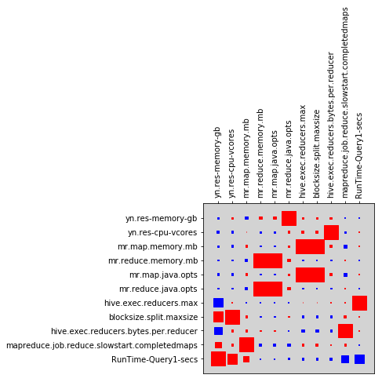

```python
# adapted from http://matplotlib.org/examples/specialty_plots/hinton_demo.html
def hinton(matrix, max_weight=None, ax=None):
    """Draw Hinton diagram for visualizing a weight matrix."""
    ax = ax if ax is not None else plt.gca()

    if not max_weight:
        max_weight = 2**np.ceil(np.log(np.abs(matrix).max())/np.log(2))

    ax.patch.set_facecolor('lightgray')
    ax.set_aspect('equal', 'box')
    ax.xaxis.set_major_locator(plt.NullLocator())
    ax.yaxis.set_major_locator(plt.NullLocator())

    for (x, y), w in np.ndenumerate(matrix):
        color = 'red' if w > 0 else 'blue'
        size = np.sqrt(np.abs(w))
        rect = plt.Rectangle([x - size / 2, y - size / 2], size, size,
                             facecolor=color, edgecolor=color)
        ax.add_patch(rect)

    nticks = matrix.shape[0]
    ax.xaxis.tick_top()
    ax.set_xticks(range(nticks))
    ax.set_xticklabels(list(matrix.columns), rotation=90)
    ax.set_yticks(range(nticks))
    ax.set_yticklabels(matrix.columns)
    ax.grid(False)

    ax.autoscale_view()
    ax.invert_yaxis()

hinton(corrmat)
```

Above we see red color for positive correlations and blue for negative correlations. So we have most correlated input paramters correlated to "RunTime-query1" are as below in a descending order:

- blocksize.split.maxsize
- hive.exec.reducers.max
- hive.exec.reducers.bytes.per.reducer
- mapreduce.job.reduce.slowstart.completedmaps
- yn.res-cpu-vcores

The function mosthighlycorrelated() will print out the linear correlation coefficients for each pair of variables in the data set, in order of the correlation coefficient. This lets you see very easily which pair of variables are most highly correlated.

### Function to find top n correlations

```python
def mosthighlycorrelated(mydataframe, numtoreport):
    # find the correlations
    cormatrix = mydataframe.corr()
    # set the correlations on the diagonal or lower triangle to zero,
    # so they will not be reported as the highest ones:
    cormatrix *= np.tri(*cormatrix.values.shape, k=-1).T
    # find the top n correlations
    cormatrix = cormatrix.stack()
    cormatrix = cormatrix.reindex(cormatrix.abs().sort_values(ascending=False).index).reset_index()
    # assign human-friendly names
    cormatrix.columns = ["FirstVariable", "SecondVariable", "Correlation"]
    return cormatrix.head(numtoreport)
```

```python
mosthighlycorrelated(tpcData, 15)
```

|  | FirstVariable | SecondVariable | Correlation |
| --- | --- | --- | --- |
| 0 | mr.reduce.memory.mb | mr.reduce.java.opts | 1.000000 |
| 1 | mr.map.memory.mb | mr.map.java.opts | 1.000000 |
| 2 | blocksize.split.maxsize | RunTime-Query1-secs | 0.505625 |
| 3 | hive.exec.reducers.max | RunTime-Query1-secs | -0.425787 |
| 4 | hive.exec.reducers.bytes.per.reducer | RunTime-Query1-secs | -0.270181 |
| 5 | mapreduce.job.reduce.slowstart.completedmaps | RunTime-Query1-secs | 0.160080 |
| 6 | mr.map.memory.mb | hive.exec.reducers.bytes.per.reducer | -0.048554 |
| 7 | mr.map.java.opts | hive.exec.reducers.bytes.per.reducer | -0.048554 |
| 8 | yn.res-memory-gb | mapreduce.job.reduce.slowstart.completedmaps | -0.037242 |
| 9 | yn.res-memory-gb | mr.reduce.memory.mb | 0.036767 |
| 10 | yn.res-memory-gb | mr.reduce.java.opts | 0.036767 |
| 11 | mr.reduce.java.opts | mapreduce.job.reduce.slowstart.completedmaps | -0.029083 |
| 12 | mr.reduce.memory.mb | mapreduce.job.reduce.slowstart.completedmaps | -0.029083 |
| 13 | yn.res-cpu-vcores | RunTime-Query1-secs | -0.027294 |
| 14 | blocksize.split.maxsize | hive.exec.reducers.bytes.per.reducer | 0.023917 |

# Standardising Variables for TPCxBB dataset

If you want to compare different variables that have different units, are very different variances, it is a good idea to first standardise the variables.

For example, we found above that the input paramters (numeric columns other than Query1-Execution-time) show a wide range of standard deviations.

As a result, it is not a good idea to use the unstandardised input paramters/independent variables as the input for a principal component analysis (PCA, see below) of the tpcdataset, as if you did that, the first principal component would be dominated by the variables which show the largest variances.

Thus, it would be a better idea to first standardise the variables so that they all have variance 1 and mean 0, and to then carry out the principal component analysis on the standardised data. This would allow us to find the principal components that provide the best low-dimensional representation of the variation in the original data, without being overly biased by those variables that show the most variance in the original data.

standardise variables can be done by using the scale() function from the package sklearn.preprocessing.

For example, to standardise the independent variables/input paramters in the hpe dataset , we type:

```python
normData= scale(tpcData)
normData= pd.DataFrame(normData, index=tpcData.index, columns=tpcData.columns)
```

```python
normData.apply(np.mean)
```

```
yn.res-memory-gb                                1.687812e-15
yn.res-cpu-vcores                              -3.030139e-17
mr.map.memory.mb                                1.199637e-16
mr.reduce.memory.mb                            -6.283813e-17
mr.map.java.opts                                1.199637e-16
mr.reduce.java.opts                            -6.283813e-17
hive.exec.reducers.max                         -1.846274e-15
blocksize.split.maxsize                        -2.739544e-16
hive.exec.reducers.bytes.per.reducer           -3.526883e-17
mapreduce.job.reduce.slowstart.completedmaps    3.737999e-17
RunTime-Query1-secs                            -2.681108e-16
dtype: float64
```

```python
normData.apply(np.std)
```

```
yn.res-memory-gb                                1.0
yn.res-cpu-vcores                               1.0
mr.map.memory.mb                                1.0
mr.reduce.memory.mb                             1.0
mr.map.java.opts                                1.0
mr.reduce.java.opts                             1.0
hive.exec.reducers.max                          1.0
blocksize.split.maxsize                         1.0
hive.exec.reducers.bytes.per.reducer            1.0
mapreduce.job.reduce.slowstart.completedmaps    1.0
RunTime-Query1-secs                             1.0
dtype: float64
```

# Principal Component Analysis

To carry out a principal component analysis (PCA) on a multivariate data set, the first step is often to standardise the variables under study using the scale() function (see above). This is necessary if the input variables have very different variances, which is true in this case. Once you have standardised your variables, you can carry out a principal component analysis using the PCA class from sklearn.decomposition package and its fit method, which fits the model with the data. The default solver is Singular Value Decomposition ("svd").

```python
pca = PCA().fit(normData)
```

You can get a summary of the principal component analysis results using the pca_summary() function below, which simulates the output of above function on a PCA model for the dataset:

```python
def pca_summary(pca, standardised_data, out=True):
    names = ["PC"+str(i) for i in range(1, len(pca.explained_variance_ratio_)+1)]
    a = list(np.std(pca.transform(standardised_data), axis=0))
    b = list(pca.explained_variance_ratio_)
    c = [np.sum(pca.explained_variance_ratio_[:i]) for i in range(1, len(pca.explained_variance_ratio_)+1)]
    columns = pd.MultiIndex.from_tuples([("sdev", "Standard deviation"), ("varprop", "Proportion of Variance"), ("cumprop", "Cumulative Proportion")])
    summary = pd.DataFrame(zip(a, b, c), index=names, columns=columns)
    if out:
        print("Importance of components:")
        display(summary)
    return summary
```

```python
summary = pca_summary(pca, normData)
```

```
Importance of components:
```

|  | sdev Standard deviation | varprop Proportion of Variance | cumprop Cumulative Proportion |
| --- | --- | --- | --- |
| PC1 | 1.421573e+00 | 1.837153e-01 | 0.183715 |
| PC2 | 1.411583e+00 | 1.811424e-01 | 0.364858 |
| PC3 | 1.313816e+00 | 1.569193e-01 | 0.521777 |
| PC4 | 1.023402e+00 | 9.521373e-02 | 0.616991 |
| PC5 | 1.009167e+00 | 9.258354e-02 | 0.709574 |
| PC6 | 9.989221e-01 | 9.071321e-02 | 0.800287 |
| PC7 | 9.947609e-01 | 8.995902e-02 | 0.890246 |
| PC8 | 9.725476e-01 | 8.598626e-02 | 0.976233 |
| PC9 | 5.113119e-01 | 2.376726e-02 | 1.000000 |
| PC10 | 3.338810e-16 | 1.096694e-33 | 1.000000 |
| PC11 | 2.205003e-16 | 3.704750e-34 | 1.000000 |

This gives us the standard deviation of each component, and the proportion of variance explained by each component. The total variance explained by the components is the sum of the variances of the components:

```python
np.sum(summary.sdev**2)
```

```
Standard deviation    11.0
dtype: float64
```

# Deciding How Many Principal Components to Retain - Independent variables (IV)

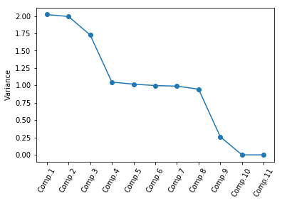

```python
def screeplot(pca, standardised_values):
    y = np.std(pca.transform(standardised_values), axis=0)**2
    x = np.arange(len(y)) + 1
    plt.plot(x, y, "o-")
    plt.xticks(x, ["Comp."+str(i) for i in x], rotation=60)
    plt.ylabel("Variance")
    plt.show()

screeplot(pca, normData)
```

Another way of deciding how many components to retain is to use Kaiser’s criterion: that we should only retain principal components for which the variance is above 1 (when principal component analysis was applied to standardised data). We can check this by finding the variance of each of the principal components:

```python
summary.sdev**2
```

|  | Standard deviation |
| --- | --- |
| PC1 | 2.020869e+00 |
| PC2 | 1.992566e+00 |
| PC3 | 1.726112e+00 |
| PC4 | 1.047351e+00 |
| PC5 | 1.018419e+00 |
| PC6 | 9.978453e-01 |
| PC7 | 9.895492e-01 |
| PC8 | 9.458488e-01 |
| PC9 | 2.614399e-01 |
| PC10 | 1.114765e-31 |
| PC11 | 4.862037e-32 |

# Loadings for the Principal Components - IV

### PC1

```python
pca.components_[0]
```

```
array([-0.02496249,  0.03060659,  0.51518286, -0.48059366,  0.51518286,
       -0.48059366,  0.00251444, -0.00851571, -0.05772764,  0.04730473,
        0.00487503])
```

```python
np.sum(pca.components_[0]**2)
```

```
0.9999999999999997
```

```python
def calcpc(variables, loadings):
    # find the number of samples in the data set and the number of variables
    numsamples, numvariables = variables.shape
    # make a vector to store the component
    pc = np.zeros(numsamples)
    # calculate the value of the component for each sample
    for i in range(numsamples):
        valuei = 0
        for j in range(numvariables):
            valueij = variables.iloc[i, j]
            loadingj = loadings[j]
            valuei = valuei + (valueij * loadingj)
        pc[i] = valuei
    return pc
```

```python
calcpc(normData, pca.components_[0])
```

```
array([0.78185182, 1.20726132, 2.59121115, ..., 2.72362562, 2.73377172,
       2.69403465])
```

In fact, the values of the first principal component are computed with the following, so we can compare those values to the ones that we calculated, and they should agree:

```python
pca.transform(normData)[:, 0]
```

```
array([0.78185182, 1.20726132, 2.59121115, ..., 2.72362562, 2.73377172,
       2.69403465])
```

# PC2:

```python
pca.components_[1]
```

```
array([ 0.04973753,  0.0160172 ,  0.48002754,  0.51447968,  0.48002754,
        0.51447968,  0.01792204, -0.05254539, -0.02643625, -0.02338169,
       -0.05206013])
```

```python
np.sum(pca.components_[1]**2)
```

```
0.9999999999999997
```

# PC3

```python
pca.components_[2]
```

```
array([-0.00592701, -0.03466771,  0.02290649,  0.04457843,  0.02290649,
        0.04457843, -0.41371866,  0.48492518, -0.24615801,  0.16213749,
        0.70748939])
```

```python
np.sum(pca.components_[2]**2)
```

```
0.9999999999999989
```

# PC4

```python
pca.components_[3]
```

```
array([-0.48585573, -0.36774376,  0.03305233,  0.03074401,  0.03305233,
        0.03074401,  0.20319153,  0.23809499,  0.49767551,  0.52779288,
       -0.02027747])
```

```python
np.sum(pca.components_[3]**2)
```

```
1.0000000000000002
```

# PC5

```python
pca.components_[4]
```

```
array([ 0.59155052, -0.13114584,  0.03133262, -0.02889595,  0.03133262,
       -0.02889595,  0.27480313,  0.5507767 ,  0.40920859, -0.28782366,
       -0.00833496])
```

```python
np.sum(pca.components_[4]**2)
```

```
0.9999999999999998
```

# PC6

```python
pca.components_[5]
```

```
array([ 0.11134126,  0.83418088, -0.02162587,  0.0175652 , -0.02162587,
        0.0175652 ,  0.23788864,  0.14468226,  0.07750799,  0.4545851 ,
        0.00372666])
```

```python
np.sum(pca.components_[5]**2)
```

```
0.9999999999999998
```

# PC7

```python
pca.components_[6]
```

```
array([ 0.15412304,  0.15014635,  0.02086218, -0.01352428,  0.02086218,
       -0.01352428, -0.69914382, -0.24374762,  0.63507051,  0.02506607,
       -0.01755108])
```

```python
np.sum(pca.components_[6])
```

```
0.018639258947693756
```

# PC8

```python
pca.components_[7]
```

```
array([-0.61194497,  0.35562605,  0.02341676,  0.00834639,  0.02341676,
        0.00834639, -0.01253208,  0.28699319,  0.1842858 , -0.61741898,
        0.01130762])
```

```python
np.sum(pca.components_[7])
```

```
-0.3401570821046276
```

# PC9

```python
pca.components_[8]
```

```
array([ 0.01589585,  0.01727944,  0.01048959, -0.00344628,  0.01048959,
       -0.00344628,  0.40762195, -0.48914098,  0.27741482, -0.1450417 ,
        0.70412662])
```

```python
np.sum(pca.components_[8])
```

```
0.8022426271937674
```

# PC10

```python
pca.components_[9]
```

```
array([-0.        , -0.        , -0.60899865, -0.35933361,  0.60899865,
        0.35933361,  0.        , -0.        ,  0.        , -0.        ,
        0.        ])
```

```python
np.sum(pca.components_[9])
```

```
2.1786108192339283e-16
```

# PC11

```python
pca.components_[10]
```

```
array([ 0.        , -0.        , -0.35933361,  0.60899865,  0.35933361,
       -0.60899865,  0.        ,  0.        , -0.        ,  0.        ,
        0.        ])
```

```python
np.sum(pca.components_[10])
```

```
2.1250542320985236e-16
```

## Scatterplots of the Principal Components

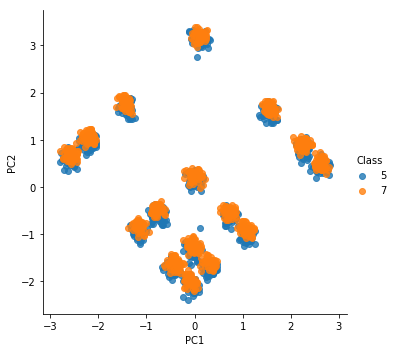

```python
def pca_scatter(pca, standardised_values, classifs):
    foo = pca.transform(standardised_values)
    bar = pd.DataFrame(zip(foo[:, 0], foo[:, 1], classifs), columns=["PC1", "PC2", "Class"])
    sns.lmplot("PC1", "PC2", bar, hue="Class", fit_reg=False)

pca_scatter(pca, normData, Cname)
```

# Principal Components Correlation

```python
iv_pc1 =pca.components_[0]
iv_pc2 =pca.components_[1]
iv_pc3 =pca.components_[2]
iv_pc4 =pca.components_[3]
iv_pc5 =pca.components_[4]
iv_pc6 =pca.components_[5]
iv_pc7 =pca.components_[6]
iv_pc8 =pca.components_[7]
iv_pc9 =pca.components_[8]
iv_pc10 =pca.components_[9]
iv_pc11 =pca.components_[10]
```

```python
pcData = pd.DataFrame(np.hstack((iv_pc1[:,None], iv_pc2[:,None], iv_pc3[:,None],iv_pc4[:,None], iv_pc5[:,None], iv_pc6[:,None], iv_pc7[:,None],iv_pc8[:,None],iv_pc9[:,None],iv_pc10[:,None],iv_pc11[:,None])))
```

```python
pcData
```

|  | 0 | 1 | 2 | 3 | 4 | 5 | 6 | 7 | 8 | 9 | 10 |
| --- | --- | --- | --- | --- | --- | --- | --- | --- | --- | --- | --- |
| 0 | -0.024962 | 0.049738 | -0.005927 | -0.485856 | 0.591551 | 0.111341 | 0.154123 | -0.611945 | 0.015896 | -1.089193e-18 | 3.938088e-18 |
| 1 | 0.030607 | 0.016017 | -0.034668 | -0.367744 | -0.131146 | 0.834181 | 0.150146 | 0.355626 | 0.017279 | -6.141854e-17 | -4.680358e-17 |
| 2 | 0.515183 | 0.480028 | 0.022906 | 0.033052 | 0.031333 | -0.021626 | 0.020862 | 0.023417 | 0.010490 | -6.089987e-01 | -3.593336e-01 |
| 3 | -0.480594 | 0.514480 | 0.044578 | 0.030744 | -0.028896 | 0.017565 | -0.013524 | 0.008346 | -0.003446 | -3.593336e-01 | 6.089987e-01 |
| 4 | 0.515183 | 0.480028 | 0.022906 | 0.033052 | 0.031333 | -0.021626 | 0.020862 | 0.023417 | 0.010490 | 6.089987e-01 | 3.593336e-01 |
| 5 | -0.480594 | 0.514480 | 0.044578 | 0.030744 | -0.028896 | 0.017565 | -0.013524 | 0.008346 | -0.003446 | 3.593336e-01 | -6.089987e-01 |
| 6 | 0.002514 | 0.017922 | -0.413719 | 0.203192 | 0.274803 | 0.237889 | -0.699144 | -0.012532 | 0.407622 | 2.659032e-17 | 1.232442e-17 |
| 7 | -0.008516 | -0.052545 | 0.484925 | 0.238095 | 0.550777 | 0.144682 | -0.243748 | 0.286993 | -0.489141 | -2.063659e-16 | 5.559192e-17 |
| 8 | -0.057728 | -0.026436 | -0.246158 | 0.497676 | 0.409209 | 0.077508 | 0.635071 | 0.184286 | 0.277415 | 1.835952e-16 | -6.279901e-17 |
| 9 | 0.047305 | -0.023382 | 0.162137 | 0.527793 | -0.287824 | 0.454585 | 0.025066 | -0.617419 | -0.145042 | -5.872592e-17 | 4.769809e-17 |
| 10 | 0.004875 | -0.052060 | 0.707489 | -0.020277 | -0.008335 | 0.003727 | -0.017551 | 0.011308 | 0.704127 | 9.299176e-17 | 6.107290e-17 |

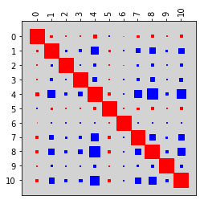

```python
pc_corrmat = pcData.T.corr()
hinton(pc_corrmat)
```

```python
pc_corrmat.columns
```

```
Int64Index([0, 1, 2, 3, 4, 5, 6, 7, 8, 9, 10], dtype='int64')
```

```python
pc_corrmat.sort_values([10],ascending=False,inplace=True)
```

```python
pc_corrmat
```

|  | 0 | 1 | 2 | 3 | 4 | 5 | 6 | 7 | 8 | 9 | 10 |
| --- | --- | --- | --- | --- | --- | --- | --- | --- | --- | --- | --- |
| 10 | 0.027328 | -0.119391 | -0.019520 | -0.045101 | -0.354618 | 0.021260 | -0.002455 | -0.125497 | -0.272894 | -0.018977 | 1.000000 |
| 0 | 1.000000 | 0.016926 | 0.002767 | 0.006394 | 0.050275 | -0.003014 | 0.000348 | 0.017792 | 0.038689 | 0.002690 | 0.027328 |
| 5 | -0.003014 | 0.013168 | 0.002153 | 0.004974 | 0.039111 | 1.000000 | 0.000271 | 0.013841 | 0.030098 | 0.002093 | 0.021260 |
| 6 | 0.000348 | -0.001521 | -0.000249 | -0.000574 | -0.004517 | 0.000271 | 1.000000 | -0.001599 | -0.003476 | -0.000242 | -0.002455 |
| 9 | 0.002690 | -0.011754 | -0.001922 | -0.004440 | -0.034911 | 0.002093 | -0.000242 | -0.012355 | -0.026866 | 1.000000 | -0.018977 |
| 2 | 0.002767 | -0.012090 | 1.000000 | -0.004567 | -0.035911 | 0.002153 | -0.000249 | -0.012709 | -0.027635 | -0.001922 | -0.019520 |
| 3 | 0.006394 | -0.027935 | -0.004567 | 1.000000 | -0.082972 | 0.004974 | -0.000574 | -0.029363 | -0.063850 | -0.004440 | -0.045101 |
| 1 | 0.016926 | 1.000000 | -0.012090 | -0.027935 | -0.219642 | 0.013168 | -0.001521 | -0.077730 | -0.169024 | -0.011754 | -0.119391 |
| 7 | 0.017792 | -0.077730 | -0.012709 | -0.029363 | -0.230876 | 0.013841 | -0.001599 | 1.000000 | -0.177669 | -0.012355 | -0.125497 |
| 8 | 0.038689 | -0.169024 | -0.027635 | -0.063850 | -0.502039 | 0.030098 | -0.003476 | -0.177669 | 1.000000 | -0.026866 | -0.272894 |
| 4 | 0.050275 | -0.219642 | -0.035911 | -0.082972 | 1.000000 | 0.039111 | -0.004517 | -0.230876 | -0.502039 | -0.034911 | -0.354618 |

- 0 - yn.res-memory-gb
- 5 - mr.reduce.java.opts

# Prediction model from the LR direct heat map

```python
from sklearn.tree import DecisionTreeRegressor
from sklearn.linear_model import LinearRegression
from sklearn.model_selection import train_test_split
from sklearn.metrics import mean_squared_error
from math import sqrt
```

From direct heap map

- blocksize.split.maxsize
- hive.exec.reducers.max
- hive.exec.reducers.bytes.per.reducer
- mapreduce.job.reduce.slowstart.completedmaps
- yn.res-cpu-vcores

```python
featuresDMLR =['blocksize.split.maxsize', 'hive.exec.reducers.max', 'hive.exec.reducers.bytes.per.reducer','mapreduce.job.reduce.slowstart.completedmaps', 'yn.res-cpu-vcores']
```

```python
targetDMLR = ['RunTime-Query1-secs']
```

```python
data.columns
```

```
Index([u'yn.res-memory-gb', u'yn.res-cpu-vcores', u'mr.map.memory.mb',
       u'mr.reduce.memory.mb', u'mr.map.java.opts', u'mr.reduce.java.opts',
       u'hive.exec.reducers.max', u'blocksize.split.maxsize',
       u'hive.exec.reducers.bytes.per.reducer',
       u'mapreduce.job.reduce.slowstart.completedmaps',
       u'RunTime-Query1-secs'],
      dtype='object')
```

```python
Xdm =data[featuresDMLR]
```

```python
Ydm=data[targetDMLR]
```

```python
X_train, X_test, y_train, y_test = train_test_split(Xdm, Ydm, test_size=0.1, random_state=112)
```

```python
regressorDM = LinearRegression()
regressorDM.fit(X_train, y_train)
```

```
LinearRegression(copy_X=True, fit_intercept=True, n_jobs=None,
         normalize=False)
```

```python
print(regressorDM.coef_)
print(regressorDM.intercept_)
```

```
[[ 0.00000006 -0.14687647 -0.00000464 14.15494755 -0.04708075]]
[216.04024319]
```

```python
X_test1=[0.75 ]
```

```python
y_prediction = regressorDM.predict(X_test)
y_prediction
```

```
array([[162.90903143],
       [187.68762594],
       [165.56685471],
       [161.30954031],
       [174.98120306],
       [155.96185392],
       [172.77805603],
       [175.86389708],
       [180.48205268],
       [196.29619362],
       [160.77152788],
       [174.28206122],
       [181.13786356],
       [145.27301296],
       [188.37934281],
       [179.84669853],
       [164.58016819],
       [180.4718784 ],
       [176.86904144],
       [169.89820645],
       [156.59357716],
       [170.76331523],
       [211.07325418],
       [172.00034274],
       [206.3919035 ],
       [177.66232176],
       [170.51025621],
       [178.92320882],
       [211.76520883],
       [175.81339292],
       [188.19953251],
       [166.99794541],
       [169.55960243],
       [168.78642331],
       [212.73499493],
       [146.42073103],
       [182.10764966],
       [194.79451006],
       [186.32817649],
       [182.20534442],
```

[output cut: 124 more lines]

```
       [172.14878118],
       [185.41098279],
       [178.63344125],
       [183.56103793],
       [212.73499493],
       [166.30123706],
       [192.58572292],
       [170.77208605],
       [159.69389915],
       [137.45541888],
       [182.04984556],
       [162.20271642],
       [163.69028699],
       [158.55047818],
       [206.02719362]])
```

```python
RMSEdm = sqrt(mean_squared_error(y_true = y_test, y_pred = y_prediction))
```

# RMSE with unstandardised data - direct correlation

```python
print(RMSEdm)
```

```
10.8973792183
```

# Prediction model from the feature extraction technicue above using pca-svd

```python
from sklearn.tree import DecisionTreeRegressor
from sklearn.linear_model import LinearRegression
from sklearn.model_selection import train_test_split
from sklearn.metrics import mean_squared_error
from math import sqrt
```

### From the correlation matrix of the principal component we have below features selected

- 0 - yn.res-memory-gb
- 5 - mr.reduce.java.opts

```python
data
```

|  | yn.res-memory-gb | yn.res-cpu-vcores | mr.map.memory.mb | mr.reduce.memory.mb | mr.map.java.opts | mr.reduce.java.opts | hive.exec.reducers.max | blocksize.split.maxsize | hive.exec.reducers.bytes.per.reducer | mapreduce.job.reduce.slowstart.completedmaps | RunTime-Query1-secs |
| --- | --- | --- | --- | --- | --- | --- | --- | --- | --- | --- | --- |
| 0 | 250880 | 63 | 8192 | 4096 | 8192 | 4096 | 295 | 67108864 | 2097152.0 | 0.75 | 162.961 |
| 1 | 245760 | 50 | 8192 | 2048 | 8192 | 2048 | 315 | 134217728 | 524288.0 | 0.90 | 192.549 |
| 2 | 240640 | 45 | 16384 | 2048 | 16384 | 2048 | 295 | 268435456 | 1048576.0 | 0.25 | 182.325 |
| 3 | 245760 | 50 | 4096 | 16384 | 4096 | 16384 | 295 | 536870912 | 524288.0 | 0.75 | 206.556 |
| 4 | 250880 | 63 | 4096 | 2048 | 4096 | 2048 | 290 | 268435456 | 1048576.0 | 0.50 | 187.959 |
| 5 | 240640 | 45 | 16384 | 16384 | 16384 | 16384 | 315 | 268435456 | 4194304.0 | 0.75 | 178.446 |
| 6 | 240640 | 63 | 2048 | 16384 | 2048 | 16384 | 315 | 134217728 | 524288.0 | 0.25 | 174.503 |
| 7 | 240640 | 63 | 4096 | 2048 | 4096 | 2048 | 295 | 134217728 | 2097152.0 | 0.25 | 158.778 |
| 8 | 240640 | 45 | 2048 | 2048 | 2048 | 2048 | 295 | 67108864 | 2097152.0 | 0.25 | 162.640 |
| 9 | 240640 | 63 | 2048 | 2048 | 2048 | 2048 | 290 | 268435456 | 4194304.0 | 0.75 | 177.117 |
| ... | ... | ... | ... | ... | ... | ... | ... | ... | ... | ... | ... |
| 1778 | 245760 | 63 | 8192 | 2048 | 8192 | 2048 | 441 | 134217728 | 2097152.0 | 0.90 | 161.305 |
| 1779 | 240640 | 45 | 2048 | 16384 | 2048 | 16384 | 430 | 268435456 | 4194304.0 | 0.90 | 160.217 |
| 1780 | 256000 | 50 | 4096 | 16384 | 4096 | 16384 | 425 | 67108864 | 524288.0 | 0.75 | 170.555 |
| 1781 | 250880 | 45 | 4096 | 2048 | 4096 | 2048 | 435 | 67108864 | 524288.0 | 0.75 | 171.663 |
| 1782 | 256000 | 45 | 16384 | 8192 | 16384 | 8192 | 425 | 268435456 | 2097152.0 | 0.75 | 161.304 |
| 1783 | 250880 | 63 | 2048 | 8192 | 2048 | 8192 | 435 | 536870912 | 4194304.0 | 0.50 | 151.724 |
| 1784 | 250880 | 63 | 2048 | 2048 | 2048 | 2048 | 441 | 268435456 | 1048576.0 | 0.25 | 173.991 |
| 1785 | 240640 | 63 | 16384 | 2048 | 16384 | 2048 | 425 | 67108864 | 2097152.0 | 0.75 | 150.368 |
| 1786 | 240640 | 50 | 16384 | 2048 | 16384 | 2048 | 430 | 268435456 | 524288.0 | 0.75 | 182.914 |
| 1787 | 250880 | 50 | 16384 | 2048 | 16384 | 2048 | 435 | 134217728 | 524288.0 | 0.75 | 176.420 |

1788 rows × 11 columns

```python
features =['yn.res-memory-gb','mr.reduce.java.opts']
```

# Specify the Prediction Target

```python
target = ['RunTime-Query1-secs']
```

```python
data.columns
```

```
Index([u'yn.res-memory-gb', u'yn.res-cpu-vcores', u'mr.map.memory.mb',
       u'mr.reduce.memory.mb', u'mr.map.java.opts', u'mr.reduce.java.opts',
       u'hive.exec.reducers.max', u'blocksize.split.maxsize',
       u'hive.exec.reducers.bytes.per.reducer',
       u'mapreduce.job.reduce.slowstart.completedmaps',
       u'RunTime-Query1-secs'],
      dtype='object')
```

```python
X =data[features]
```

```python
Y=data[target]
```

```python
X
```

|  | yn.res-memory-gb | mr.reduce.java.opts |
| --- | --- | --- |
| 0 | 250880 | 4096 |
| 1 | 245760 | 2048 |
| 2 | 240640 | 2048 |
| 3 | 245760 | 16384 |
| 4 | 250880 | 2048 |
| 5 | 240640 | 16384 |
| 6 | 240640 | 16384 |
| 7 | 240640 | 2048 |
| 8 | 240640 | 2048 |
| 9 | 240640 | 2048 |
| ... | ... | ... |
| 1778 | 245760 | 2048 |
| 1779 | 240640 | 16384 |
| 1780 | 256000 | 16384 |
| 1781 | 250880 | 2048 |
| 1782 | 256000 | 8192 |
| 1783 | 250880 | 8192 |
| 1784 | 250880 | 2048 |
| 1785 | 240640 | 2048 |
| 1786 | 240640 | 2048 |
| 1787 | 250880 | 2048 |

1788 rows × 2 columns

```python
Y
```

|  | RunTime-Query1-secs |
| --- | --- |
| 0 | 162.961 |
| 1 | 192.549 |
| 2 | 182.325 |
| 3 | 206.556 |
| 4 | 187.959 |
| 5 | 178.446 |
| 6 | 174.503 |
| 7 | 158.778 |
| 8 | 162.640 |
| 9 | 177.117 |
| ... | ... |
| 1778 | 161.305 |
| 1779 | 160.217 |
| 1780 | 170.555 |
| 1781 | 171.663 |
| 1782 | 161.304 |
| 1783 | 151.724 |
| 1784 | 173.991 |
| 1785 | 150.368 |
| 1786 | 182.914 |
| 1787 | 176.420 |

1788 rows × 1 columns

# Split the Dataset into Training and Test Datasets

```python
X_train, X_test, y_train, y_test = train_test_split(X, Y, test_size=0.1, random_state=112)
```

# (1) Linear Regression: Fit a model to the training set

```python
regressor = LinearRegression()
regressor.fit(X_train, y_train)
```

```
LinearRegression(copy_X=True, fit_intercept=True, n_jobs=None,
         normalize=False)
```

```python
print(regressor.coef_)
print(regressor.intercept_)
```

```
[[-0.00009755  0.00000923]]
[200.31340907]
```

# Perform Prediction using Linear Regression Model

```python
y_prediction = regressor.predict(X_test)
y_prediction
```

```
array([[175.87712467],
       [175.91491676],
       [175.41544582],
       [176.98944286],
       [175.49103001],
       [175.85822862],
       [176.98944286],
       [176.35769957],
       [176.37659562],
       [176.35769957],
       [176.91385866],
       [175.85822862],
       [176.48997191],
       [175.37765372],
       [175.91491676],
       [176.35769957],
       [175.91491676],
       [175.99050096],
       [175.87712467],
       [175.41544582],
       [176.91385866],
       [176.87606656],
       [176.35769957],
       [175.35875767],
       [175.99050096],
       [176.85717052],
       [175.41544582],
       [176.87606656],
       [175.41544582],
       [176.85717052],
       [176.48997191],
       [175.35875767],
       [176.48997191],
       [175.41544582],
       [175.35875767],
       [176.37659562],
       [175.99050096],
       [175.35875767],
       [176.98944286],
       [176.91385866],
```

[output cut: 124 more lines]

```
       [176.48997191],
       [175.87712467],
       [176.48997191],
       [176.41438771],
       [176.91385866],
       [175.87712467],
       [175.35875767],
       [175.99050096],
       [175.37765372],
       [176.85717052],
       [176.48997191],
       [176.91385866],
       [176.41438771],
       [176.35769957],
       [175.87712467]])
```

# What is the mean of the expected target value in test set ?

```python
y_test.describe()
```

|  | RunTime-Query1-secs |
| --- | --- |
| count | 179.000000 |
| mean | 177.658089 |
| std | 20.503194 |
| min | 135.541000 |
| 25% | 162.620500 |
| 50% | 174.577000 |
| 75% | 189.281000 |
| max | 241.101000 |

# Evaluate Linear Regression Accuracy using Root Mean Square Error

```python
RMSE = sqrt(mean_squared_error(y_true = y_test, y_pred = y_prediction))
```

```python
print(RMSE)
```

```
20.5644711645
```